# Does AI Raise Wages or Displace Workers?

A TANK-CW Experiment on Task Automation vs. Labor-Augmenting AI

## The Question We Are Asking

Not all AI is the same. A factory robot that replaces a line worker is economically distinct from software that helps that worker do twice as much in the same shift. The first *displaces* a human task; the second *augments* human productivity. Both raise output. But they have opposite effects on wages, the labor share, and the distribution of income between workers and capital owners.

This experiment uses a medium-scale TANK-CW (Two-Agent New Keynesian model with Capital and Wealth) to ask: **what happens when the same AI shock is routed entirely into automation versus entirely into labor-augmenting productivity — and what happens at every point in between?**

We find that the type of AI shock matters enormously for distribution, and somewhat for monetary policy. Output looks similar across all three cases. Wages, labor share, and worker consumption tell completely different stories.

## The Setup

The model has two types of agents:

- **Workers** ($\lambda \approx 0.80$ of the population): hand-to-mouth households who supply labor and consume their wage income each period.
- **Capitalists** ($1-\lambda \approx 0.20$): saver households who own the capital stock and receive profits and capital returns.

The economy has sticky prices and sticky wages, government spending and debt, and variable capital utilization. The key new ingredient is the **task allocation block**, which gives the model an Acemoglu-Restrepo flavor.

A single AI innovation shock, $\varepsilon_t^{AI}$, can be split between two channels by the parameter $\phi_{disp} \in [0,1]$:

$$Z_t = \rho_Z Z_{t-1} + (1 - \phi_{disp})\,\varepsilon_t^{AI} + \varepsilon_t^Z
\tag{1}$$

$$I_t = \rho_{AI}\, I_{t-1} + \phi_{disp}\,\varepsilon_t^{AI}
\tag{2}$$

- When $\phi_{disp} = 0$: the entire shock loads into $Z_t$, the **labor-augmenting productivity** term. AI makes every worker more productive — wages rise with productivity, gains are broadly shared.
- When $\phi_{disp} = 1$: the entire shock loads into $I_t$, the **automation technology frontier**. AI replaces human tasks — output rises but wages fall and labor share collapses.
- When $\phi_{disp} = 0.5$: the shock is evenly split between the two channels.

Both shocks are near-permanent ($\rho_Z = \rho_{AI} = 0.999$), representing the kind of durable structural shift AI might represent.

We compare the full impulse responses across all three values.

## The Task Allocation Block: An Acemoglu-Restrepo Approximation

### Conceptual Background

In Acemoglu and Restrepo (2018, 2019), production is organized as a continuum of tasks indexed on $[0,1]$. At each point in time, tasks $[0, I^*]$ are performed by machines (automated) and tasks $[I^*, 1]$ are performed by humans.

Two forces determine the equilibrium automated task share $I^*$:

1. **The technology frontier** $I_t$: what *can* be automated, given the current state of AI. When AI advances, $I_t$ rises.
2. **The cost-minimizing threshold** $\tilde{I}_t$: what *should* be automated, given relative factor prices. When wages rise relative to capital rental costs, firms want to automate more tasks.

In the full AR system, $I^* = \min\{I_t,\, \tilde{I}_t\}$: automation expands until either the technology ceiling or the cost floor is hit.

### The Linearized Approximation Used Here

The full AR task integral structure is not modeled explicitly. Instead we use a linear blend that approximates the AR assignment rule in the neighborhood of a technology-constrained steady state (where $I_t < \tilde{I}_t$, so the technology frontier is the binding constraint):

$$\tilde{I}_t = \chi^{I}_{wr}\,(W_t - RK_t)
\tag{3}$$

$$I^*_t = \omega_I\, I_t + (1 - \omega_I)\,\tilde{I}_t
\tag{4}$$

Equation (3) says firms want to automate more tasks whenever wages rise relative to the capital rental rate. The parameter $\chi^I_{wr} = 0.40$ is the elasticity of the cost-minimizing threshold to relative factor costs.

Equation (4) is the linearized analog of AR’s $\min\{\cdot\}$ rule. With $\omega_I = 0.90$ (close to 1), the equilibrium task share largely tracks the technology frontier $I_t$, not the firm’s cost preference. This approximates a world where firms are *technology constrained* rather than *price constrained* — they would automate more tasks if they could, but the AI hasn’t gotten there yet.

### Task-Based Production and Factor Prices

Once we know $I^*_t$, the production block reads:

$$Y^W_t = (1-\alpha)\,(Z_t + H_t) + \alpha\,(U_t + K_{t-1}) + \chi^{Y}_{I}\, I^*_t
\tag{5}$$

$$MPL^{human}_t = Y^W_t - \chi^{MPL}_{I}\, I^*_t - H_t
\tag{6}$$

$$MPK_t = Y^W_t + \chi^{MPK}_{I}\, I^*_t - U_t - K_{t-1}
\tag{7}$$

$$W_t = MC_t + MPL^{human}_t
\tag{8}$$

Three $\chi$ coefficients capture the task-reallocation effects that in the full AR model would come from integrating over the automated task margin:

| Parameter | Value | Meaning |
| --- | --- | --- |
| $\chi^Y_I = 0.67$ | Output rises as more tasks are automated |  |
| $\chi^{MPL}_I = 0.67$ | **Displacement effect**: higher $I^*$ shrinks the human task set, compressing human MPL |  |
| $\chi^{MPK}_I = 0.33$ | **Complementarity effect**: automation makes capital more valuable |  |

The displacement effect in equation (6) is the heart of the AR mechanism. When $I^*$ rises, machines take over more tasks; the remaining tasks done by humans constitute a smaller share of the production process, so the marginal product of an additional hour of human labor falls. Wages fall with it.

## Results

We ran the model three times under the AI displacement shock $\varepsilon_t^{AI}$, setting $\phi_{disp} \in \{0,\, 0.5,\, 1\}$.

### Impulse Response Comparison

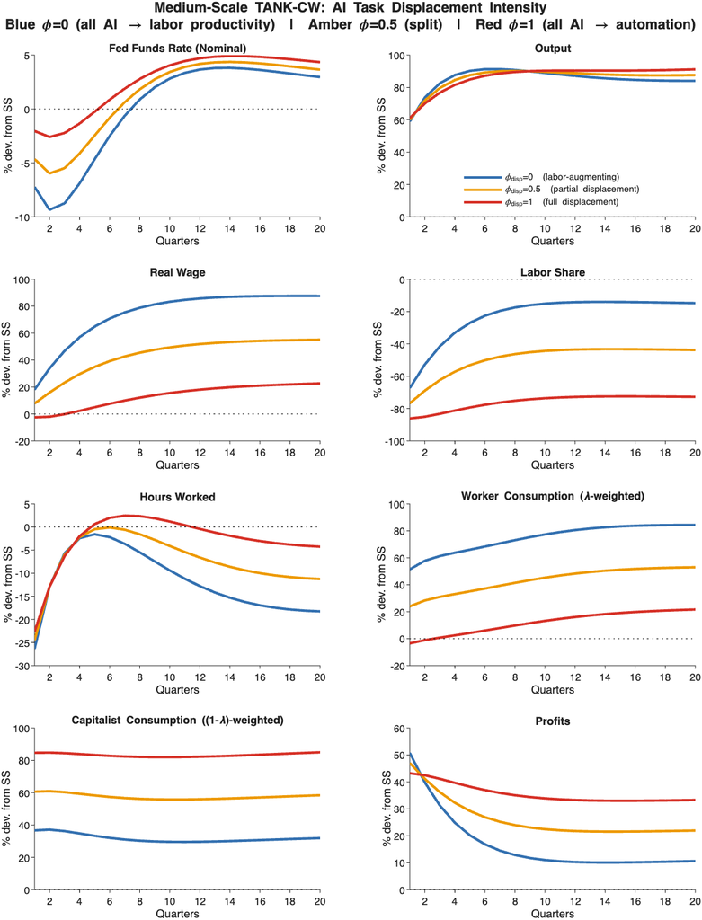

**Figure 1.** Impulse responses to a one-unit AI shock across three displacement intensities. **Blue**: $\phi_{disp} = 0$ (pure labor-augmenting AI, all gains go through $Z$). **Amber**: $\phi_{disp} = 0.5$ (half augmenting, half displacement). **Red**: $\phi_{disp} = 1$ (pure automation, all gains go through $I$). All variables shown as percent deviations from steady state. Horizon: 20 quarters.

### Reading the Eight Panels

**Panel 1 — Fed Funds Rate (Nominal):** Zero means the nominal interest rate is at its steady-state value — monetary policy is neutral and the Fed is responding to nothing. All three lines dip below zero, meaning the Fed cuts rates after the AI shock. But the cut is dramatically larger under blue ($-0.072$ at impact) than under red ($-0.020$). Under labor-augmenting AI, the sharp productivity boom drives a large disinflationary swing through marginal costs, triggering an aggressive Fed response. Under displacement, the disinflation is far smaller — the Fed barely moves. (See Section 4.1 for the full explanation.)

**Panel 2 — Output:** Zero means output is at its pre-shock steady-state level — the economy is producing exactly as much as before the AI arrived. All three scenarios raise output above zero permanently, as you would expect from a near-permanent AI shock. But note that output is *slightly higher* under displacement ($Y_1 = 0.610$) than under augmentation ($Y_1 = 0.590$). The automation channel generates a small additional output dividend on top of the standard productivity boost, because it directly adds to production via $\chi^Y_I I^*_t$ while also freeing capital to be utilized more intensively.

**Panel 5 — Hours Worked:** Zero means workers are putting in the same number of hours per week as before the AI shock. All three scenarios reduce hours below zero — workers work less after AI arrives. But counterintuitively, *hours fall the least under displacement*. Under augmentation (blue), wages rise, making workers wealthier; they use part of that wealth to buy leisure (the income effect on labor supply), and hours fall by $-0.264$. Under displacement (red), wages fall; workers cannot afford as much leisure, so the income effect works in reverse and they maintain closer to their pre-shock hours (hours fall by only $-0.226$). They are working harder precisely because they are earning less per hour. (See Section 4.2 for more detail.)

**Panel 6 — Worker Consumption ($\lambda$-weighted):** Zero means aggregate worker consumption equals its steady-state level — workers are buying the same total amount as they were before AI. Blue is far above zero: higher wages raise worker income, so workers consume substantially more. Red dips below zero at impact: wages fall, and because workers are largely hand-to-mouth consumers, their consumption contracts immediately with their income. Workers are worse off in absolute consumption terms under full displacement — even in a world where the economy is producing slightly more output.

**Panel 7 — Capitalist Consumption ($(1-\lambda)$-weighted):** Zero means the consumption of the capitalist household equals its steady-state share of aggregate consumption. All three lines are above zero — capitalists are unambiguously better off under all AI scenarios. But the gain is largest under displacement (red). Automation boosts capital returns through the MPK complementarity channel ($\chi^{MPK}_I I^*_t$ in equation (7)), raising the value of the capital stock. Forward-looking capitalists immediately consume more against this permanent increase in capital income. Under augmentation, capitalists also gain but must share the output dividend with workers, so their consumption rise is smaller.

**Panel 8 — Profits:** Zero means firm profits are at their steady-state level — shareholders are receiving the normal return on capital, no windfall. All three lines are above zero: AI raises profitability in every scenario. Interestingly, blue has slightly higher impact profits ($0.508$) than red ($0.432$), even though capitalist consumption is much higher under red. The resolution: the large output boom from augmentation generates more total surplus in period 1. But under displacement, the task-automation channel raises the *permanent* path of capital returns (through higher MPK), so capitalists can borrow against future profits and consume more today even if current-period profits are marginally lower.

### Impact Response Table

| $\phi_{disp}$ | $Y_1$ | $W_1$ | $LS_1$ | $H_1$ | $\pi_1$ | $R_{n,1}$ | profits$_1$ | $CHl_1$ | $CSl_1$ |
| --- | --- | --- | --- | --- | --- | --- | --- | --- | --- |
| 0.00 (blue) | 0.590 | 0.180 | −0.673 | −0.264 | −0.161 | −0.072 | 0.508 | 0.514 | 0.367 |
| 0.50 (amber) | 0.600 | 0.078 | −0.767 | −0.245 | −0.103 | −0.046 | 0.470 | 0.240 | 0.607 |
| 1.00 (red) | 0.610 | −0.025 | −0.861 | −0.226 | −0.045 | −0.020 | 0.432 | −0.035 | 0.846 |

## Specific Questions

### 4.1 Why Does the Fed Cut Rates Less Under Displacement?

At first this seems backward. AI displaces workers and compresses wages — shouldn’t that be deflationary and trigger bigger rate cuts?

The key is how each AI type transmits to inflation through **marginal cost**. In the New Keynesian Phillips curve,

$$\pi_t = \beta\, E_t[\pi_{t+1}] + \kappa\, MC_t,$$

inflation responds to the real marginal cost $MC_t$. And $MC_t = W_t - MPL_t^{human}$ (the wage per unit of human marginal product).

Under **labor-augmenting AI** ($\phi_{disp} = 0$): $Z$ jumps sharply. Human MPL surges because every hour of labor now generates more output. Wages rise (0.180) but MPL rises by even more. The denominator of marginal cost explodes relative to the numerator, so $MC$ falls dramatically ($MC_1 \approx -0.67$). This is a big deflationary supply shock. The Taylor rule triggers large rate cuts ($R_{n,1} = -0.072$).

Under **displacement AI** ($\phi_{disp} = 1$): $I^*$ rises, which simultaneously raises output *and* compresses human MPL via equation (6). Wages also fall $(-0.025)$. Both the numerator (wages) and denominator (human MPL) of marginal cost move in the same direction. The net fall in $MC$ is much smaller ($MC_1 \approx -0.27$). Less disinflation means the Fed barely needs to respond ($R_{n,1} = -0.020$).

**The punchline**: under augmentation, productivity gains flow to human workers, dramatically cutting unit labor costs and generating strong deflation. Under displacement, productivity gains come from replacing human tasks with machines; the compression of human MPL mutes the fall in marginal costs, so inflation barely moves and the Fed cuts very little. Displacement is less disinflationary, which is why rate cuts shrink as $\phi_{disp}$ rises.

### 4.2 Why Are Hours and Output Higher Under Displacement?

**Hours are higher under displacement** (less negative: $-0.226$ vs $-0.264$ for blue).

When labor-augmenting AI raises wages, workers are wealthier per hour worked. Standard theory says higher permanent income leads households to consume more leisure — the income effect pushes hours *down*. Under augmentation, this income effect is strong and hours fall significantly.

When displacement AI *lowers* wages, workers are poorer per hour worked. The income effect now runs in reverse: workers cannot afford as much leisure and maintain more hours. In addition, the lower wage weakens the substitution effect (leisure is relatively cheaper when wages are low, pushing toward more leisure), but in this calibration the income effect dominates at the margin, so workers with lower wages end up working more hours than workers who got a wage raise. They are, in a real sense, running harder on the treadmill precisely because it got slower.

**Output is higher under displacement** ($Y_1 = 0.610$ vs $0.590$ for blue).

Under displacement, production receives an additional boost from the direct automation term $\chi^Y_I I^*_t$ in equation (5). When $\phi_{disp} = 1$ and $I^*_1 \approx 0.882$, this term adds approximately $0.67 \times 0.882 = 0.59$ to wholesale output on top of all other factor contributions. Under augmentation, the shock goes into $Z$, which enters production as $(1-\alpha) \times Z_t$ with $1-\alpha = 0.67$, so a unit $Z$ shock adds $0.67$ — similar in magnitude. But under displacement, hours also fall *less*, so the human labor input is slightly higher. These two small advantages combine to make displacement marginally more productive in the first period.

This is the disturbing arithmetic of task displacement: it produces more output and employs people for more hours than the “nice” scenario, yet wages fall, labor share collapses, and workers consume less. More work, more output, less pay.

## Task-Allocation Internals

The following table shows what happens inside the AR approximation block in the impact quarter:

| $\phi_{disp}$ | $I_1$ (`AI_disp`) | $\tilde{I}_1$ | $I^*_1$ |
| --- | --- | --- | --- |
| 0.00 | 0.000 | 0.092 | 0.009 |
| 0.50 | 0.500 | −0.043 | 0.446 |
| 1.00 | 1.000 | −0.179 | 0.882 |

Under augmentation ($\phi_{disp} = 0$): the technology frontier $I_t$ does not move. The cost-minimizing threshold $\tilde{I}$ rises slightly because wages rise relative to capital costs, but with $\omega_I = 0.90$, the equilibrium $I^*$ barely budges ($0.009$). No displacement occurs.

Under displacement ($\phi_{disp} = 1$): the technology frontier jumps to 1.0. The cost-minimizing threshold actually *falls* (−0.179), because automation lowers wages relative to capital costs — firms would prefer *less* automation on pure cost grounds. But the technology frontier dominates ($\omega_I = 0.90$), so $I^*$ rises to 0.882. This is the technology-constrained regime: firms automate because they can, even though falling wages would ordinarily argue for less automation.

## Two Figures Side by Side

For comparison, Figure 2 shows the two extreme cases (Scenario A, pure $Z$ shock vs. Scenario B, pure $I$ shock) from separate model files, using the same impulse response window.

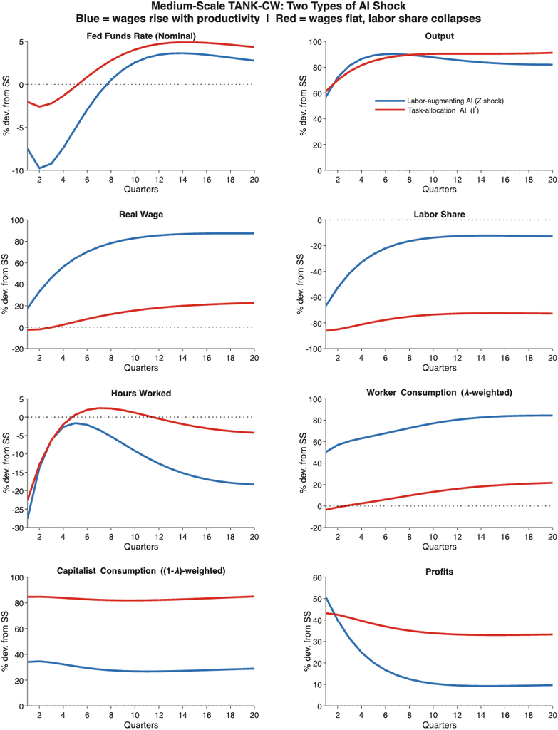

In Figure 2, the contrast becomes even starker at longer horizons. The blue line for real wages keeps rising toward a permanently higher level, as the near-permanent productivity shift feeds through sticky wages into a new, higher wage level. The red line for labor share remains far below zero permanently — there is no mechanism in the model for the labor share to recover once automation has re-routed tasks to machines.

## Blog Post Notes

### How to Describe This to a General Audience

**Describing the Acemoglu-Restrepo approximation for a blog:**

Think of the economy as a list of tasks: write the report, drive the truck, file the claim, diagnose the scan. At any moment, some tasks are done by machines and some by humans. The dividing line between them — economists call it the “automation frontier” — can shift over time as AI improves.

When AI advances the automation frontier, firms can take tasks that were previously human-only and reassign them to machines. The humans who were doing those tasks don’t disappear from the economy, but they have fewer tasks available to them. With a smaller task set, each additional hour of human labor produces less, so firms are willing to pay less per hour. This is the displacement effect: the human marginal product of labor falls, and wages follow.

This model captures that mechanism in a simplified but internally consistent way. Instead of modeling the full continuum of tasks (which Acemoglu and Restrepo do in their 2018 and 2019 papers), we use a single state variable $I^*_t$ to represent the share of tasks currently automated. When AI pushes $I^*$ up, the production function rewards machines more and penalizes human labor — captured by the $-\chi^{MPL}_I I^*_t$ term in the human marginal product equation. The coefficient $\chi^{MPL}_I = 0.67$ reflects the degree to which automating an additional fraction of tasks compresses human MPL, calibrated to match standard labor-share estimates.

**Key messages for the blog:**

1. **Same output, different distribution.** All three $\phi_{disp}$ values produce roughly the same GDP path. The question of “how much AI raises output” is largely independent of the question “who benefits.”
2. **The Fed is not a neutral arbiter.** Displacement AI is less disinflationary than augmenting AI. This means the Fed cuts rates less under displacement, providing less stimulus to an economy where workers are already losing ground. Monetary policy cannot easily offset distributional damage from task automation.
3. **More hours, less pay.** Under full displacement, workers actually work more hours than under augmentation, because falling wages weaken the income effect that would otherwise allow them to take more leisure. This is a stark illustration of how aggregate statistics (hours, output) can be misleading about worker welfare.
4. **Capital wins most under displacement.** Capitalist consumption rises 0.846 units under full displacement versus 0.367 under pure augmentation. Automation complements capital both through higher MPK and through the permanent income channel as forward-looking capitalists borrow against the future stream of capital returns.
5. **Policy implication.** If the goal is to share AI gains broadly, the type of AI policy matters. Subsidizing AI that augments workers (training, tools, software that raises human productivity) has very different distributional consequences from subsidizing AI that automates tasks (robotics, autonomous systems). This model gives a structural framework for thinking through those tradeoffs.

## Appendix: Full LaTeX for the Task Allocation Block

```latex
\subsubsection*{Task Allocation Block (Acemoglu--Restrepo Approximation)}

Let $I_t$ denote the technology-feasible automation frontier (what AI can
currently automate), $\tilde{I}_t$ the cost-minimizing automation threshold
(what firms would choose based on relative factor prices), and $I^*_t$ the
equilibrium automated task share.

\paragraph{Cost-minimizing threshold}
\begin{equation}
  \tilde{I}_t = \chi^{I}_{wr}\bigl(W_t - RK_t\bigr)
  \label{eq:Itilde}
\end{equation}
Firms want to automate more tasks whenever wages rise relative to the capital
rental rate. $\chi^I_{wr} > 0$ is the elasticity of the cost-minimizing
threshold to relative factor prices.

\paragraph{Equilibrium automated task share}
\begin{equation}
  I^*_t = \omega_I\, I_t + (1-\omega_I)\,\tilde{I}_t
  \label{eq:Istar}
\end{equation}
This is the linearized analog of Acemoglu--Restrepo's assignment rule
$I^* = \min\{I,\tilde{I}\}$. With $\omega_I$ close to 1, the economy
is in the technology-constrained regime: automation tracks the frontier,
not firms' cost preferences.

\paragraph{Task-based production function}
\begin{equation}
  Y^W_t = (1-\alpha)\bigl(Z_t + H_t\bigr) + \alpha\bigl(U_t + K_{t-1}\bigr)
          + \chi^{Y}_{I}\, I^*_t
  \label{eq:YW}
\end{equation}
Output rises as more tasks are automated ($\chi^Y_I > 0$).

\paragraph{Human marginal product of labor (displacement effect)}
\begin{equation}
  MPL^{human}_t = Y^W_t - \chi^{MPL}_{I}\, I^*_t - H_t
  \label{eq:MPL}
\end{equation}
Higher $I^*$ compresses the set of tasks available to human workers,
lowering human MPL. This is the core displacement channel.

\paragraph{Marginal product of capital (complementarity effect)}
\begin{equation}
  MPK_t = Y^W_t + \chi^{MPK}_{I}\, I^*_t - U_t - K_{t-1}
  \label{eq:MPK}
\end{equation}
Automation raises the marginal return to capital as machines and capital
are complements in automated production.

\paragraph{Real wage}
\begin{equation}
  W_t = MC_t + MPL^{human}_t
  \label{eq:wage}
\end{equation}

\paragraph{AI shock decomposition}
\begin{align}
  Z_t     &= \rho_Z\, Z_{t-1} + (1-\phi_{disp})\,\varepsilon_t^{AI}
             + \varepsilon_t^Z
             \label{eq:Z} \\
  I_t     &= \rho_{AI}\, I_{t-1} + \phi_{disp}\,\varepsilon_t^{AI}
             \label{eq:I}
\end{align}
$\phi_{disp} = 0$: pure labor-augmenting AI. $\phi_{disp} = 1$: pure
automation. All values in between represent a mixed shock.
```

## Appendix: Full Linearized Equation System

$$u'(c^S)_t = Pr_t - \sigma_c\, c^S_t \tag{1. Capitalist MU}$$

$$u'(c^S)_t = r_t + u'(c^S)_{t+1} \tag{2. Capitalist Euler}$$

$$u'(n^S)_t = 0, \quad n^S_t = 0 \tag{3. Capitalists supply no labor}$$

$$u'(c^W)_t = Pr_t - \sigma_c\, c^W_t \tag{4. Worker MU}$$

$$u'(n^W)_t = \varphi\, n^W_t \tag{5. Worker disutility of labor}$$

$$mrs_t = u'(n^W)_t - u'(c^W)_t \tag{6. Worker MRS}$$

$$u'(c^W)_t = r_t + u'(c^W)_{t+1} - \tfrac{\psi^W}{\bar{c}^W}\, b^W_t \tag{7. Worker Euler}$$

$$c^W_t + \tfrac{b^W_t}{\bar{c}^W} = \tfrac{\bar{W}\bar{n}^W}{\bar{c}^W}(w_t + n^W_t) - \tfrac{\bar{t}^W}{\bar{c}^W}\,t^W_t + \tfrac{\tau^d}{\lambda}\tfrac{d_t}{\bar{c}^W} + \tfrac{\bar{R}\, b^W_{t-1}}{\bar{c}^W} \tag{8. Worker budget}$$

$$\tilde{I}_t = \chi^I_{wr}(w_t - r^K_t) \tag{9. Cost-min automation threshold}$$

$$I^*_t = \omega_I\, I_t + (1-\omega_I)\,\tilde{I}_t \tag{10. Equilibrium task share}$$

$$y^m_t = (1-\alpha)(z_t + n_t) + \alpha(u_t + k_{t-1}) + \chi^Y_I\, I^*_t \tag{11. Task-based production}$$

$$y_t = y^m_t\,(1 + F/\bar{Y}) \tag{12. Retail output}$$

$$mpl^{human}_t = y^m_t - \chi^{MPL}_I\, I^*_t - n_t \tag{13. Human MPL, displacement effect}$$

$$w_t = mc_t + mpl^{human}_t \tag{14. Real wage}$$

$$mpk_t = y^m_t + \chi^{MPK}_I\, I^*_t - u_t - k_{t-1} \tag{15. MPK, capital complementarity}$$

$$r^K_t = mc_t + mpk_t \tag{16. Capital rental rate}$$

$$y_t = \tfrac{\bar{W}\bar{n}}{\bar{Y}}(w_t + n_t) + \tfrac{\bar{R}^K\bar{K}}{\bar{Y}}(r^K_t + u_t + k_{t-1}) + \tfrac{d_t}{\bar{Y}} \tag{17. Income identity}$$

$$d_t = d^S_t \tag{18. Profits to capitalists}$$

$$ls_t = w_t + n_t - y_t \tag{19. Labor share}$$

$$r^K_t = \tfrac{\gamma_2}{\gamma_1}\, u_t \tag{20. Variable capital utilization}$$

$$k^S_t = \delta(i^S_t + zi_t) + (1-\delta)\, k^S_{t-1} \tag{21. Capital law of motion}$$

$$R_t - \pi_{t+1} = \beta(1-\delta)\, q_{t+1} + [1-\beta(1-\delta)]\, r^K_{t+1} - q_t \tag{22. Capital arbitrage / Tobin's Q}$$

$$(1+\bar{R}^{-1})\, i^S_t = \bar{R}^{-1}\, i^S_{t+1} + i^S_{t-1} + \tfrac{1}{2\iota}(q_t + zi_t) \tag{23. Investment Euler}$$

$$i_t = i^S_t, \quad k_t = k^S_t \tag{24. Investment and capital aggregation}$$

$$y_t = c_y\, c_t + g_y\, g_t + \imath_y\, i_t + \tfrac{\gamma_1\bar{K}}{\bar{Y}}\, u_t \tag{25. Resource constraint}$$

$$r_t = R_t - \pi_{t+1} \tag{26. Fisher equation}$$

$$c_t = \lambda\, c^W_t + (1-\lambda)\, c^S_t \tag{27. Consumption aggregation}$$

$$n_t = n^W_t \tag{28. Labor aggregation}$$

$$\pi_t = \beta\, \pi_{t+1} + \kappa\,(mc_t + ms_t) \tag{29. New Keynesian Phillips curve}$$

$$\pi^w_t = \beta\, \pi^w_{t+1} + \kappa_w\,(mrs_t - w_t + wms_t) \tag{30. Wage Phillips curve}$$

$$\pi^w_t = w_t - w_{t-1} \tag{31. Wage inflation}$$

$$R_t = \rho_r\, R_{t-1} + (1-\rho_r)(\phi_\pi \pi_t + \phi_y y_t) + \varepsilon^M_t \tag{32. Taylor rule}$$

$$z_t = \rho_Z\, z_{t-1} + (1-\phi_{disp})\,\varepsilon^{AI}_t + \varepsilon^Z_t \tag{33. Labor-augmenting tech}$$

$$I_t = \rho_{AI}\, I_{t-1} + \phi_{disp}\,\varepsilon^{AI}_t \tag{34. Automation frontier}$$

$$g_t = \rho_G\, g_{t-1} + \varepsilon^G_t \tag{35. Gov. spending shock}$$

$$b_t = \bar{R}(b_{t-1} + r_{t-1}) + \tfrac{\bar{G}}{\bar{B}}\,g_t - \tfrac{\bar{t}}{\bar{B}}\,t_t \tag{36. Gov. budget constraint}$$

$$b_t = b^S_t + \lambda\, b^W_t/\bar{B} \tag{37. Bond market clearing}$$

$$t_t = \rho_\tau\, t_{t-1} + \phi_{\tau B}\, b_{t-1} + \phi_{\tau G}\, g_t \tag{38. Fiscal rule}$$

$$t^S_t = \tfrac{1-\lambda}{\lambda}\,t_t, \quad t^W_t = \tfrac{\lambda}{1-\lambda}\,t_t \tag{39. Tax allocation}$$

$$ms_t = \rho_{MS}\, ms_{t-1} + \varepsilon^{MS}_t \tag{40. Price markup shock}$$

$$wms_t = \rho_{WMS}\, wms_{t-1} + \varepsilon^{WMS}_t \tag{41. Wage markup shock}$$

$$Pr_t = \rho_{Pr}\, Pr_{t-1} + \varepsilon^{Pr}_t \tag{42. Preference shock}$$

$$zi_t = \rho_{ZI}\, zi_{t-1} + \varepsilon^{ZI}_t \tag{43. MEI shock}$$